# Cyclistic Case Study

Melvin Chang

09 May, 2025

## Introduction

This is a case study for a fictional bike-share company called Cyclistic as part of the Google Data Analytics Capstone Project.

Cyclistic launched its bike-share program in 2016 which has grown to a fleet of 5,824 bicycles which are geotracked and locked into a network of 692 stations across Chicago. The bikes can be unlocked from one station and returned to any other station in the system at any time.

The company offers single-ride passes, full-day passes, and annual memberships. Customers who purchase single-ride or full-day passes are referred to as casual rider. Customers who purchase annual memberships are Cyclistic members.

Cyclistic’s finance analysts have concluded that annual members are much more profitable than casual riders. The director of marketing believes that the company’s future success depends on maximizing the number of annual memberships. Thus, the goal of the director of marketing is to design marketing strategies which aim to convert casual riders into annual members. However, before doing so, the team needs to have a better understanding of **how annual members and casual riders differ**, why casual riders would buy a membership, and how digital media could affect their marketing tactics. They would like to analyze the Cyclistic historical bike trip data to identify trends.

The data that was used for this case study was for the year 2024 which can be found [here](https://divvy-tripdata.s3.amazonaws.com/index.html).

## Questions

Three questions will guide the future marketing program:

1. How do annual members and casual riders use Cyclistic bikes differently?
2. Why would casual riders buy Cyclistic annual memberships?
3. How can Cyclistic use digital media to influence casual riders to become members?

For this case study, I am tasked to answer the first question: How do annual members and casual riders use Cyclistic bikes differently?

## Import libraries

```r
library(ggplot2)
library(hms)
library(scales)
library(tidyverse)
```

## Import data

To begin our analysis, we import the cleaned dataset. This dataset has already been partially processed in Python, where the original 12 monthly datasets were merged and efforts were made to fill in missing values in the `start_station_name`, `start_station_id`, `end_station_name`, and `end_station_id` columns. No missing values should remain in any column.

```r
# Import bike data for the months Jan 2024 - Dec 2024
bike_data_2024 <- read_csv("data/cleaned_data.csv")
```

## Data wrangling

We start by inspecting the dataset to ensure the structure and content meet our expectations.

```r
glimpse(bike_data_2024)
```

```
## Rows: 5,813,769
## Columns: 13
## $ ride_id            <chr> "C1D650626C8C899A", "EECD38BDB25BFCB0", "F4A9CE7806…
## $ rideable_type      <chr> "electric_bike", "electric_bike", "electric_bike", …
## $ started_at         <dttm> 2024-01-12 15:30:27, 2024-01-08 15:45:46, 2024-01-…
## $ ended_at           <dttm> 2024-01-12 15:37:59, 2024-01-08 15:52:59, 2024-01-…
## $ start_station_name <chr> "Wells St & Elm St", "Wells St & Elm St", "Wells St…
## $ start_station_id   <chr> "KA1504000135", "KA1504000135", "KA1504000135", "TA…
## $ end_station_name   <chr> "Kingsbury St & Kinzie St", "Kingsbury St & Kinzie …
## $ end_station_id     <chr> "KA1503000043", "KA1503000043", "KA1503000043", "13…
## $ start_lat          <dbl> 41.90327, 41.90294, 41.90295, 41.88430, 41.94880, 4…
## $ start_lng          <dbl> -87.63474, -87.63444, -87.63447, -87.63396, -87.675…
## $ end_lat            <dbl> 41.88918, 41.88918, 41.88918, 41.92182, 41.88918, 4…
## $ end_lng            <dbl> -87.63851, -87.63851, -87.63851, -87.64414, -87.638…
## $ member_casual      <chr> "member", "member", "member", "member", "member", "…
```

```r
colSums(is.na(bike_data_2024)) > 0
```

```
##            ride_id      rideable_type         started_at           ended_at
##              FALSE              FALSE              FALSE              FALSE
## start_station_name   start_station_id   end_station_name     end_station_id
##              FALSE              FALSE              FALSE              FALSE
##          start_lat          start_lng            end_lat            end_lng
##              FALSE              FALSE              FALSE              FALSE
##      member_casual
##              FALSE
```

The data types for each column are as expected, and there are no missing values in the dataset. However, we should rename the `member_casual` column to `rider_type` for readability.

```r
bike_data_2024 <- bike_data_2024 |>
    rename(rider_type = member_casual)
```

Next, we will remove any duplicate data if it exists to ensure that the dataset contains only unique observations.

```r
# Remove rows that are complete duplicates of other rows
bike_data_2024 <- distinct(bike_data_2024)
```

To further support our analysis, we add two new columns to help with the analysis: `ride_duration`, which captures the duration of each ride, and `day_of_week`, indicates which day of the week the ride took place on.

```r
# Add column for duration of the ride is HH:MM:SS
bike_data_2024 <- bike_data_2024 |>
    mutate(duration_secs = as.numeric(difftime(ended_at, started_at, units = "secs"))) |>
    mutate(ride_duration = as_hms(duration_secs))

# Add column for day of the week
bike_data_2024 <- bike_data_2024 |>
    mutate(day_of_week = weekdays(as.Date(started_at)))
```

We can now check if there are any abnormalities.

```r
bike_data_2024 |>
    select(duration_secs, ride_duration) |>
    summary()
```

```
##  duration_secs       ride_duration
##  Min.   :-164899.0   Min.   :-45:48:19.000000
##  1st Qu.:    332.1   1st Qu.: 00:05:32.126000
##  Median :    581.7   Median : 00:09:41.735000
##  Mean   :    928.9   Mean   : 00:15:28.879557
##  3rd Qu.:   1031.5   3rd Qu.: 00:17:11.456000
##  Max.   :  90562.0   Max.   : 25:09:22.000000
```

Based on the summary, we can see that there are negative values, as well as ride durations over 24 hours. It is not possible for ride lengths to be of negative lengths, and it is unreasonable for some rides to occur for over 24 hours. To further clean this data, we can begin by filtering out any rows which have a duration less than or equal to zero.

```r
bike_data_2024 <- bike_data_2024 |>
    filter(duration_secs > 0)
```

After removing values less than or equal to zero, we can remove outliers using the IQR method. This helps eliminate rides with unusually long durations that could distort our analysis.

```r
Q1 <- quantile(bike_data_2024$duration_secs, 0.25)
Q3 <- quantile(bike_data_2024$duration_secs, 0.75)
IQR <- Q3 - Q1

lower_bound <- Q1 - 1.5 * IQR
upper_bound <- Q3 + 1.5 * IQR

# Filter out the outliers from the data set
bike_data_2024 <- bike_data_2024 |>
    filter(duration_secs >= lower_bound & duration_secs <= upper_bound)
```

## Exploratory Data Analysis

We can begin the analysis by calculating summary statistics for ride durations.

```r
bike_data_2024 |>
    summarize(
        Min_Ride_Length = format(as_hms(min(ride_duration))),
        Max_Ride_Length = format(as_hms(max(ride_duration))),
        Average_Ride_Length = format(as_hms(mean(ride_duration)))
        )
```

```
## # A tibble: 1 × 3
##   Min_Ride_Length Max_Ride_Length Average_Ride_Length
##   <chr>           <chr>           <chr>
## 1 00:00:00.039    00:34:40.566    00:10:55.736869
```

The shortest recorded ride lasted only 0.039 seconds, likely due to a false start or system error. Meanwhile, the longest ride lasted for 34 minutes, and the average ride duration is approximately 11 minutes.

Next, we can examine how ride frequency varies by day of the week.

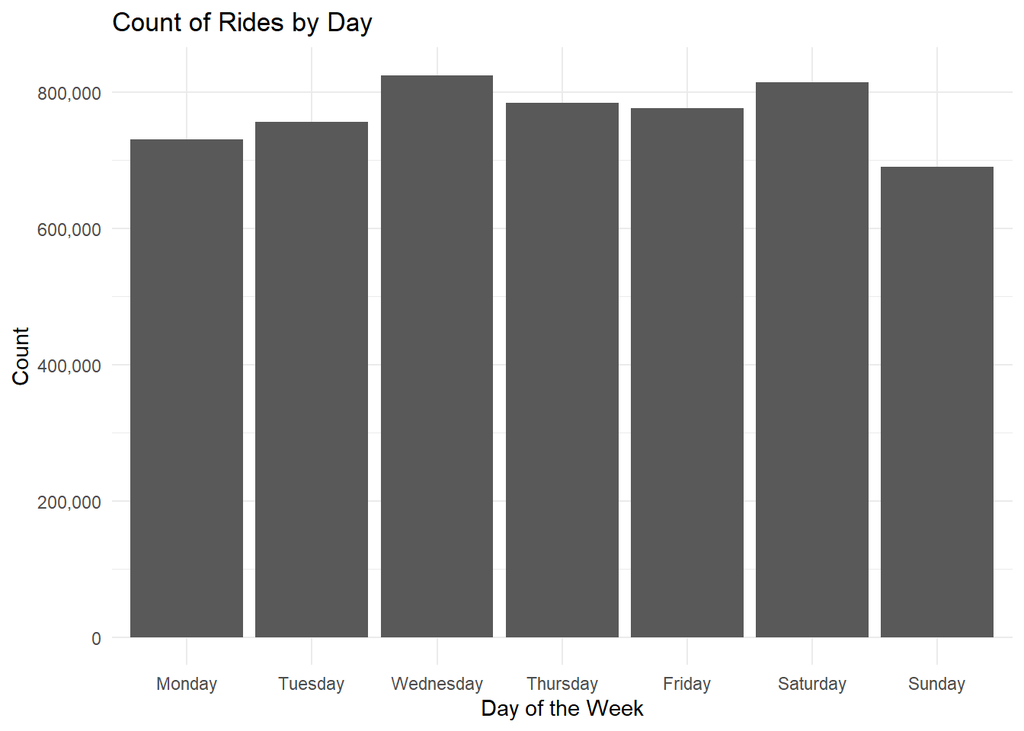

```r
# Plot bar graph for ride count by day of week
bike_data_2024 |>
    mutate(
        day_of_week = factor(day_of_week,
        levels = c("Monday", "Tuesday", "Wednesday", "Thursday", "Friday", "Saturday", "Sunday"))) |>
    ggplot(aes(x=day_of_week)) +
    geom_bar() +
    scale_y_continuous(labels = comma) +
    labs(
        title="Count of Rides by Day",
        x="Day of the Week",
        y="Count") +
    theme_minimal()
```

```r
# Shows count of rides by the day of the week from largest to lowest
bike_data_2024 |>
    count(day_of_week) |>
    arrange(desc(n))
```

```
## # A tibble: 7 × 2
##   day_of_week      n
##   <chr>        <int>
## 1 Wednesday   825085
## 2 Saturday    814551
## 3 Thursday    784325
## 4 Friday      776491
## 5 Tuesday     756665
## 6 Monday      730741
## 7 Sunday      690745
```

To further explore this, we break down the ride frequency by the rider type and day of the week.

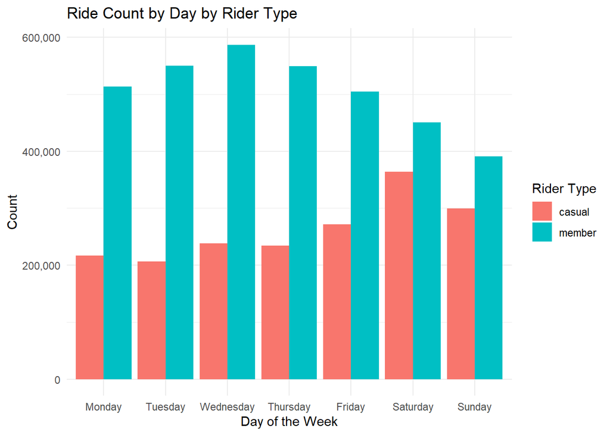

```r
# Bar graph to show the count of rides by day of the week, by rider type
bike_data_2024 |>
    mutate(
        day_of_week = factor(day_of_week,
        levels = c("Monday", "Tuesday", "Wednesday", "Thursday", "Friday", "Saturday", "Sunday"))) |>
    ggplot(aes(x=day_of_week, fill=rider_type)) +
    geom_bar(position = "dodge") +
    scale_y_continuous(labels = comma) +
    labs(
        title = "Ride Count by Day by Rider Type",
        x = "Day of the Week",
        y = "Count",
        fill = "Rider Type") +
    theme_minimal()
```

The chart shows a distinct trend between members and casual riders. Annual members take more rides on weekdays, while casual riders are more active on weekends. This suggests that members may primarily use the service for commuting to work, while casual riders are more likely to ride for leisure.

Next, we investigate how ride duration varies by day of the week and by rider type.

```r
# Average ride duration by the day of the week
bike_data_2024 |>
    mutate(day_of_week = factor(day_of_week,
        levels = c("Monday", "Tuesday", "Wednesday", "Thursday", "Friday", "Saturday", "Sunday"))) |>
    group_by(day_of_week) |>
    summarize(Average_Ride_Length = format(as_hms(mean(ride_duration))))
```

```
## # A tibble: 7 × 2
##   day_of_week Average_Ride_Length
##   <fct>       <chr>
## 1 Monday      00:10:27.126746
## 2 Tuesday     00:10:23.266146
## 3 Wednesday   00:10:33.887005
## 4 Thursday    00:10:29.526116
## 5 Friday      00:10:46.889356
## 6 Saturday    00:12:00.125387
## 7 Sunday      00:11:51.450739
```

```r
# Average ride duration by member type
bike_data_2024 |>
    group_by(rider_type) |>
    summarize(Average_Ride_Length = format(as_hms(mean(ride_duration))))
```

```
## # A tibble: 2 × 2
##   rider_type Average_Ride_Length
##   <chr>      <chr>
## 1 casual     00:12:12.251331
## 2 member     00:10:16.217759
```

Weekday rides average around 10.5 minutes, while weekend rides average closer to 12 minutes.

Members ride for an average of 10 minutes and 16 seconds, whereas casual riders average 12 minutes and 12 seconds – a difference of nearly 2 minutes. Although casual members appear to have longer bike rides by about 2 minutes compared to annual members, we will want to delve deeper to ensure that this difference isn’t skewed by a small number of long rides.

We’ll visualize the full distribution of ride durations for each type of rider using a density plot.

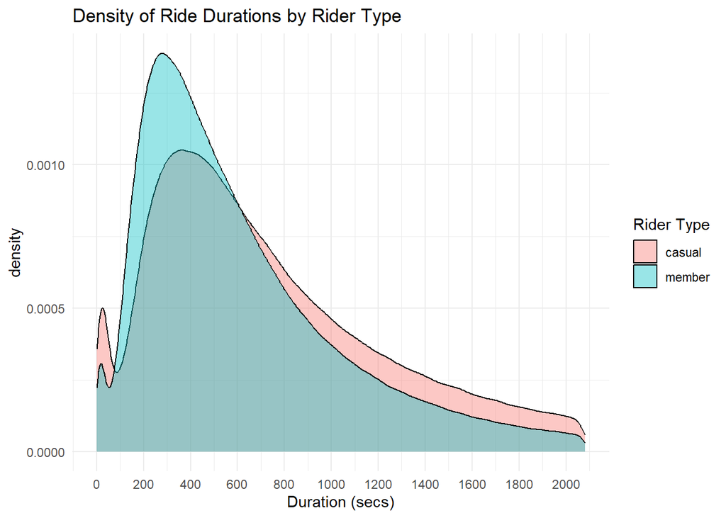

```r
# Density plot to visualize the distribution
bike_data_2024 |>
    ggplot(aes(x = duration_secs, fill = rider_type)) +
    geom_density(alpha = 0.4) +
    scale_x_continuous(breaks = seq(0, 2000, by = 200)) +
    scale_y_continuous(labels = comma) +
    labs(
        title = "Density of Ride Durations by Rider Type",
        x = "Duration (secs)",
        fill = "Rider Type") +
    theme_minimal()
```

From this plot, we observe a right-skewed curve for both types of riders. Annual members maintain a higher concentration of rides between ride lengths of 1 minute and 40 seconds to 10 minutes long. On the other hand, casual riders are more likely to take trips lasting over 10 minutes compared to members. To confirm whether this difference is statistically significant, we perform a t-test on the length of the bike ride by the rider type.

```r
t.test(duration_secs ~ rider_type, data = bike_data_2024)
```

```
##
##  Welch Two Sample t-test
##
## data:  duration_secs by rider_type
## t = 274.34, df = 3333452, p-value < 2.2e-16
## alternative hypothesis: true difference in means between group casual and group member is not equal to 0
## 95 percent confidence interval:
##  115.2046 116.8625
## sample estimates:
## mean in group casual mean in group member
##             732.2513             616.2178
```

The t-test results indicate that the p-value is effectively 0 which means that the difference in ride duration between casual riders and annual members is statistically significant. The t-test confirms that casual riders will average approximately 116 seconds longer than annual members with a 95% confidence interval between 115.20 seconds and 116.86 seconds.

To validate this further, we can perform a linear regression on the ride duration by rider type.

```r
lm(duration_secs ~ rider_type, data = bike_data_2024) |>
    summary()
```

```
##
## Call:
## lm(formula = duration_secs ~ rider_type, data = bike_data_2024)
##
## Residuals:
##    Min     1Q Median     3Q    Max
## -732.2 -332.8 -114.4  234.2 1464.3
##
## Coefficients:
##                   Estimate Std. Error t value Pr(>|t|)
## (Intercept)       732.2513     0.3304  2216.0   <2e-16 ***
## rider_typemember -116.0336     0.4069  -285.1   <2e-16 ***
## ---
## Signif. codes:  0 '***' 0.001 '**' 0.01 '*' 0.05 '.' 0.1 ' ' 1
##
## Residual standard error: 447.2 on 5378601 degrees of freedom
## Multiple R-squared:  0.01489,    Adjusted R-squared:  0.01489
## F-statistic: 8.131e+04 on 1 and 5378601 DF,  p-value: < 2.2e-16
```

The results from the linear model supports the results generated from the t-test. The model clearly predicts that ride durations for annual members are shorter with a coefficient of -116.03 seconds.

We will also assess whether the type of rideable bike influences the ride duration. Riders can choose between a classic bike, electric bike, and electric scooter.

```r
# Show summary of bike types
bike_data_2024 |>
  group_by(rideable_type) |>
  summarize(
    average_duration = format(as_hms(mean(duration_secs))),
    ride_count = n()
  )
```

```
## # A tibble: 3 × 3
##   rideable_type    average_duration ride_count
##   <chr>            <chr>                 <int>
## 1 classic_bike     00:11:54.750245     2427768
## 2 electric_bike    00:10:10.473018     2811136
## 3 electric_scooter 00:09:01.004886      139699
```

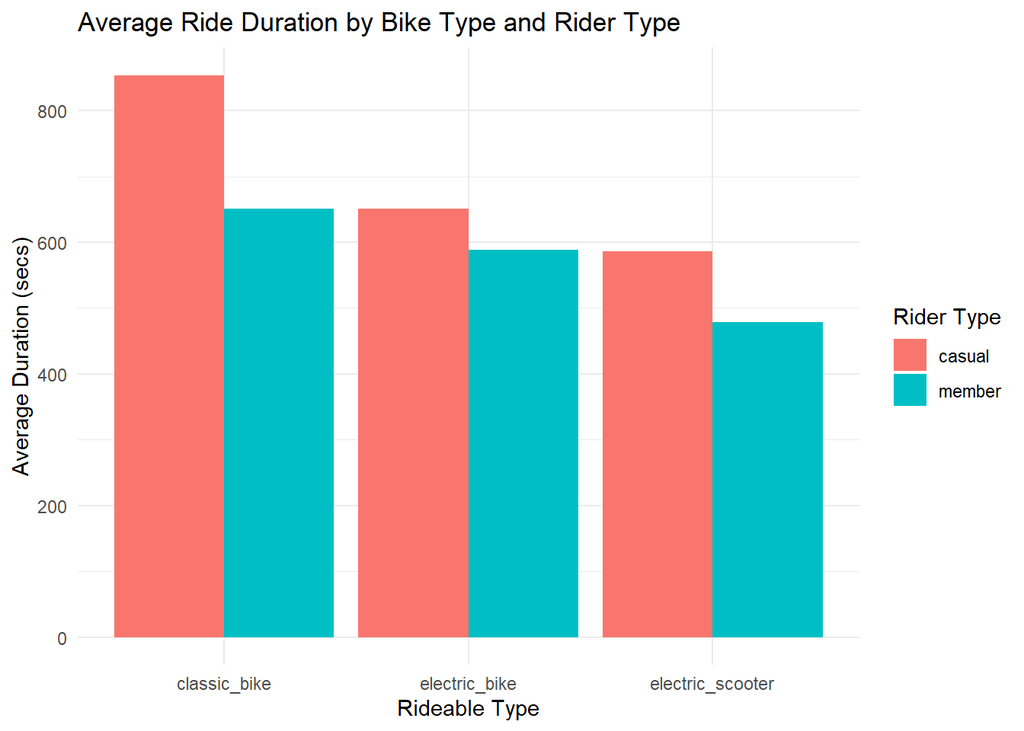

```r
# Plot of average ride duration by bike type and rider type
bike_data_2024 |>
  group_by(rider_type, rideable_type) |>
  summarise(mean_duration = mean(duration_secs)) |>
  ggplot(aes(x = rideable_type, y = mean_duration, fill = rider_type)) +
  geom_col(position = "dodge") +
  labs(
    title = "Average Ride Duration by Bike Type and Rider Type",
    x = "Rideable Type",
    y = "Average Duration (secs)",
    fill="Rider Type") +
  theme_minimal()
```

The averages for the three bike types clearly indicate how the electric variants result in a shorter average ride duration. Rides on classic bikes last for ~2 minutes longer than electric bike rides, and ~3 minutes longer than electric scooter rides. Similarly to the rider type, we will test the significance of the bike types on the average duration of a ride.

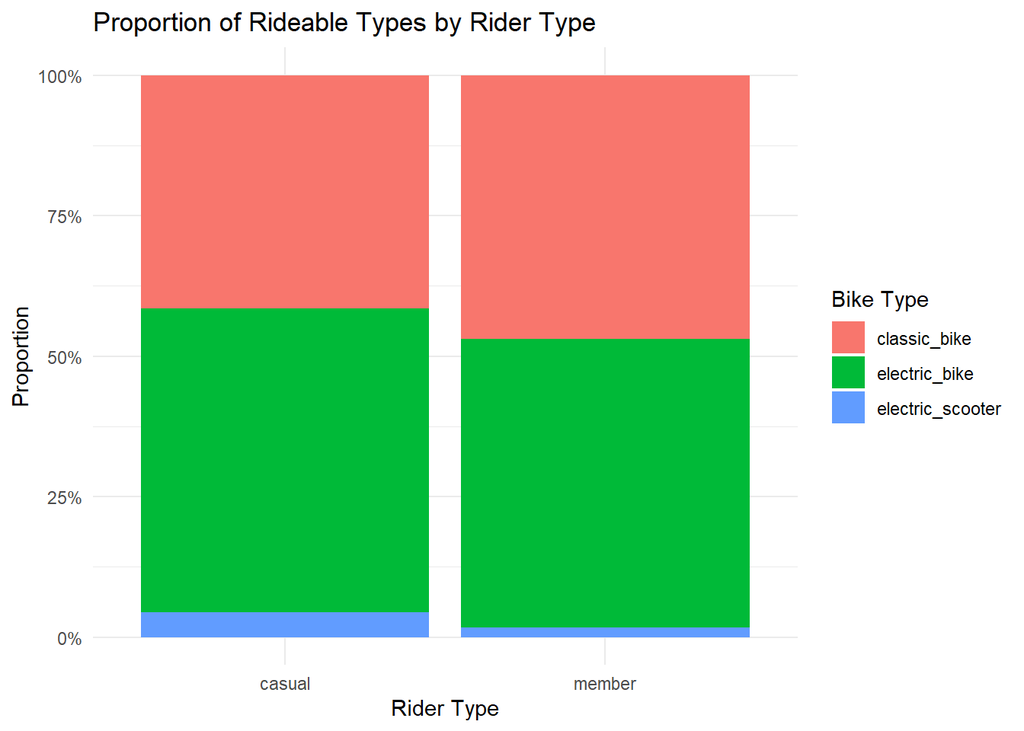

```r
# Calculate ratio between bike types by rider types
rideable_ratio <- bike_data_2024 |>
    count(rider_type, rideable_type) |>
    group_by(rider_type) |>
    mutate(proportion = n / sum(n))

# Plot the proportions onto a stacked bar graph
rideable_ratio |>
    ggplot(aes(x = rider_type, y = proportion, fill = rideable_type)) +
    geom_col() +
    scale_y_continuous(labels = percent) +
    labs(
        title = "Proportion of Rideable Types by Rider Type",
        x = "Rider Type",
        y = "Proportion",
        fill = "Bike Type") +
    theme_minimal()
```

```r
rideable_ratio
```

```
## # A tibble: 6 × 4
## # Groups:   rider_type [2]
##   rider_type rideable_type          n proportion
##   <chr>      <chr>              <int>      <dbl>
## 1 casual     classic_bike      761618     0.416
## 2 casual     electric_bike     989196     0.540
## 3 casual     electric_scooter   81049     0.0442
## 4 member     classic_bike     1666150     0.470
## 5 member     electric_bike    1821940     0.514
## 6 member     electric_scooter   58650     0.0165
```

The graph and summary above shows that the distribution of rideable types is relatively consistent between casual riders and annual members, indicating that both groups tend to use electric bikes, classic bikes, and scooters in similar proportions.

Finally, we perform a two-way ANOVA to assess the influence of both rider type and rideable type on ride duration.

```r
aov(duration_secs ~ rider_type * rideable_type, data = bike_data_2024) |>
    summary()
```

```
##                               Df    Sum Sq   Mean Sq F value Pr(>F)
## rider_type                     1 1.626e+10 1.626e+10   83170 <2e-16 ***
## rideable_type                  2 1.840e+10 9.198e+09   47039 <2e-16 ***
## rider_type:rideable_type       2 5.702e+09 2.851e+09   14579 <2e-16 ***
## Residuals                5378597 1.052e+12 1.955e+05
## ---
## Signif. codes:  0 '***' 0.001 '**' 0.01 '*' 0.05 '.' 0.1 ' ' 1
```

The ANOVA results support the earlier observations about the impact of rider type on ride duration. The extremely low p-values for both rider type and rideable type indicate that these factors significantly influence average ride duration. In particular, the significant main effect for rider type confirms that casual and member riders differ in how long they ride, while the significant main effect for rideable type shows that the type of bike or scooter also impacts ride time. The interaction effect between rider type and rideable type is also statistically significant, meaning the impact of bike type on duration varies depending on the user group.

However, because the proportion of rideable types used by each rider type is roughly similar, the shorter average ride durations observed for annual members are unlikely to be fully explained by differences in bike type usage. This suggests that membership status itself, and the likely usage intent (e.g., commuting vs. leisure) plays a more substantial role in determining the length of the ride than the bike type alone.

## Conclusion

Our analysis of the 2024 ride data reveals consistent and statistically significant differences in ride durations between casual riders and annual members. Casual riders tend to take longer rides, particularly on weekends, which would align with leisure-oriented use. In contrast, members take shorter, more frequent rides, predominantly on weekdays, suggesting usage for commuting.

While rideable type (classic bike, electric bike, or electric scooter) does impact average ride duration, both types of riders use these options in similar proportions. Therefore, the bike type alone does not explain the shorter ride times among members. Instead, the analysis points to the rider type, and the likely purpose behind each ride as the primary driver of observed differences in ride durations.

Understanding that casual riders enjoy longer, less frequent rides opens an opportunity to pitch membership benefits that align with their behavior. This could include deals such as offering flexible or discounted weekend ride bundles, or tiered memberships with perks for extended trips. Highlighting cost savings for frequent long-distance riders or convenience features like reserved bike availability may appeal to casual users who ride semi-regularly.

Digital media can be leveraged to target casual riders with personalized messaging based on their ride history. Similarly to music-based applications, digital media can be used to provide an end-of-the-year recap summarizing the rider’s statistics for the year. This recap could incorporate stats like the length of their longest ride, the total amount of distance they’ve ridden for the year, or even the most common locations they like to take their rides ons.

Opportunities for further analysis could include:

- Seasonal trends and weather impacts on rider behavior
- Popular routes and stations for optimized bike distributions
- Modeling ride patterns across different times of day and days of the week